# Investigate_a_Dataset

Project: Investigate a Dataset - International Migrant Stock

Introduction

Description

The data analyzed is obtained from Gapminder. This project visualizes migration patterns around the world by analyzing population data of foreign born individuals.

immigrant_n refers to the number of foreign born individuals in a country permanently.

emigrant_n refers to the number of individuals moving out of a country permanently.

Questions for Analysis

i. Which countries have the highest increase of population through migration?

ii. Which countries have the highest decrease of population through migration?

iii. Which country most reduced emigration over the last 10 years?

Import Statements

```python
import numpy as np
import pandas as pd
import matplotlib.pyplot as plt
import seaborn as sns
% matplotlib inline
```

Data Wrangling

```python
dfi = pd.read_csv('immigrant_n.csv')
dfe = pd.read_csv('emigrant_n.csv')
dfe.head()
```

|  | country | 1989 | 1990 | 1991 | 1992 | 1993 | 1994 | 1995 | 1996 | 1997 | ... | 2010 | 2011 | 2012 | 2013 | 2014 | 2015 | 2016 | 2017 | 2018 | 2019 |
| --- | --- | --- | --- | --- | --- | --- | --- | --- | --- | --- | --- | --- | --- | --- | --- | --- | --- | --- | --- | --- | --- |
| 0 | Afghanistan | 7.68M | NaN | NaN | NaN | NaN | 4.35M | NaN | NaN | NaN | ... | NaN | NaN | NaN | NaN | 5.4M | NaN | NaN | NaN | NaN | 5.85M |
| 1 | Angola | 825k | NaN | NaN | NaN | NaN | 689k | NaN | NaN | NaN | ... | NaN | NaN | NaN | NaN | 618k | NaN | NaN | NaN | NaN | 668k |
| 2 | Albania | 180k | NaN | NaN | NaN | NaN | 501k | NaN | NaN | NaN | ... | NaN | NaN | NaN | NaN | 1.14M | NaN | NaN | NaN | NaN | 1.25M |
| 3 | Andorra | 3740 | NaN | NaN | NaN | NaN | 4140 | NaN | NaN | NaN | ... | NaN | NaN | NaN | NaN | 8740 | NaN | NaN | NaN | NaN | 11.1k |
| 4 | United Arab Emirates | 79.5k | NaN | NaN | NaN | NaN | 97.9k | NaN | NaN | NaN | ... | NaN | NaN | NaN | NaN | 178k | NaN | NaN | NaN | NaN | 203k |

5 rows × 32 columns

```python
#dfi.shape
#dfe.describe()
#dfi.info()
```

The data has columns with missing data. The table was populated with data representing 5 year intervals from 1989 to 2019. Therefore, every year without data can be dropped without disrupting the integrity of the data.

```python
dfe=dfe.dropna(axis=1, how='all')
dfi=dfi.dropna(axis=1, how='all')
```

Data Cleaning

The data is astype objects. Since this is population data, it is converted to float, keeping in mind that values for k is 1,000 and M is 1,000,000.

```python
def value_to_float(x):
    if type(x) == float or type(x) == int:
        return x
    if 'k' in x:
        if len(x) > 1:
            return float(x.replace('k', '')) * 1000
        return 1000.0
    if 'M' in x:
        if len(x) > 1:
            return float(x.replace('M', '')) * 1000000
        return 1000000.0
    return 0.0

mig_columns = ['1989', '1994', '1999', '2004', '2009', '2014', '2019']
for c in mig_columns:
    dfe[c] = dfe[c].apply(value_to_float)
    dfi[c] = dfi[c].apply(value_to_float)
```

Rows with zero values are converted to null and all rows with null are dropped as they do not add to the analysis.

```python
mig_columns = ['1989', '1994', '1999', '2004', '2009', '2014', '2019']
for c in mig_columns:
    dfi[c]=dfi[c].loc[~(dfi[c]==0)]
    dfe[c]=dfe[c].loc[~(dfe[c]==0)]
```

```python
dfe = dfe.dropna(how='any',axis=0)
dfi = dfi.dropna(how='any',axis=0)
```

Inner merge is performed to ensure only countries with data in both datasets are included.

```python
df_net = dfi.merge(dfe, left_on='country', right_on='country', how='inner')
#df_net
```

Copies of the dataframe are created

```python
dfi_new = df_net[['country', '1989_x', '1994_x', '1999_x', '2004_x', '2009_x', '2014_x', '2019_x' ]].copy()
dfe_new = df_net[['country', '1989_y', '1994_y', '1999_y', '2004_y', '2009_y', '2014_y', '2019_y'  ]].copy()
```

The copies are renamed for wrangling

```python
dfi_new=dfi_new.rename(columns=lambda x: x[:4])
dfe_new=dfe_new.rename(columns=lambda x: x[:4])
```

The copies are subtracted from each other to get the net migration. Negative sign indicates more people left the country, while positive indicates more people moved in.

```python
df = dfi_new.set_index('coun').subtract(dfe_new.set_index('coun'), fill_value=0)
df.head()
```

| coun | 1989 | 1994 | 1999 | 2004 | 2009 | 2014 | 2019 |
| --- | --- | --- | --- | --- | --- | --- | --- |
| Afghanistan | -7622300.0 | -4278500.0 | -4674100.0 | -4032700.0 | -5168000.0 | -5061000.0 | -5706000.0 |
| Angola | -791500.0 | -649200.0 | -866900.0 | -654700.0 | -315000.0 | 14000.0 | -12000.0 |
| Albania | -114000.0 | -429600.0 | -747300.0 | -901300.0 | -1067200.0 | -1088000.0 | -1201200.0 |
| United Arab Emirates | 1230500.0 | 1722100.0 | 2339000.0 | 3154000.0 | 7164000.0 | 7822000.0 | 8517000.0 |
| Argentina | 1220000.0 | 1118000.0 | 984000.0 | 865000.0 | 871000.0 | 1146000.0 | 1200000.0 |

The table is sorted in ascending order for 2019 to reflect the country with most leaving at the top, to the country most receiving at the bottom.

```python
d_tot = df.sort_values('2019')
```

d_emi represents top 10 countries for emigrants. d_imm represents top 10 countries for immigrants.

```python
d_emi = d_tot.head(10)
d_imm = d_tot.tail(10)
```

Reindexing

```python
d_emi = d_emi.reset_index(level=0)
d_imm = d_imm.reset_index(level=0)
df = df.reset_index(level=0)
```

```python
d_emi
```

|  | coun | 1989 | 1994 | 1999 | 2004 | 2009 | 2014 | 2019 |
| --- | --- | --- | --- | --- | --- | --- | --- | --- |
| 0 | India | 970000.0 | -200000.0 | -1520000.0 | -3650000.0 | -7630000.0 | -10690000.0 | -13020000.0 |
| 1 | Mexico | -3704000.0 | -6491000.0 | -9022000.0 | -10087000.0 | -11430000.0 | -10890000.0 | -10000000.0 |
| 2 | China | -3854000.0 | -4588000.0 | -5372000.0 | -6661000.0 | -7860000.0 | -9222000.0 | -9460000.0 |
| 3 | Syria | 94000.0 | 170000.0 | 128000.0 | 69000.0 | 720000.0 | -5614000.0 | -7591000.0 |
| 4 | Philippines | -1856000.0 | -2273000.0 | -2742000.0 | -3423000.0 | -4481000.0 | -5288000.0 | -5864000.0 |
| 5 | Afghanistan | -7622300.0 | -4278500.0 | -4674100.0 | -4032700.0 | -5168000.0 | -5061000.0 | -5706000.0 |
| 6 | Bangladesh | -4568000.0 | -4485000.0 | -4452000.0 | -4430000.0 | -4970000.0 | -5410000.0 | -5280000.0 |
| 7 | Indonesia | -1154000.0 | -1561000.0 | -2128000.0 | -2491000.0 | -3113000.0 | -3732000.0 | -4244000.0 |
| 8 | Venezuela | 845000.0 | 778000.0 | 692000.0 | 643000.0 | 789000.0 | 691000.0 | -4100000.0 |
| 9 | Poland | -540000.0 | -815000.0 | -1225000.0 | -2157000.0 | -3078000.0 | -3468000.0 | -4013000.0 |

```python
d_emi=d_emi.rename({'coun': 'country'}, axis=1)
d_imm=d_imm.rename({'coun': 'country'}, axis=1)
df=df.rename({'coun': 'country'}, axis=1)
d_imm.head(10)
```

|  | country | 1989 | 1994 | 1999 | 2004 | 2009 | 2014 | 2019 |
| --- | --- | --- | --- | --- | --- | --- | --- | --- |
| 0 | Italy | -1920000.0 | -1440000.0 | -950000.0 | 1250000.0 | 3230000.0 | 3150000.0 | 3130000.0 |
| 1 | United Kingdom | -140000.0 | 450000.0 | 870000.0 | 1780000.0 | 2690000.0 | 4030000.0 | 4630000.0 |
| 2 | Spain | -618000.0 | -340000.0 | 370000.0 | 3000000.0 | 5190000.0 | 4620000.0 | 5350000.0 |
| 3 | France | 4680000.0 | 4740000.0 | 4720000.0 | 5010000.0 | 5350000.0 | 5760000.0 | 6180000.0 |
| 4 | Canada | 3336000.0 | 3800000.0 | 4370000.0 | 4890000.0 | 5490000.0 | 6170000.0 | 6760000.0 |
| 5 | Australia | 3659000.0 | 3809000.0 | 4008000.0 | 4451000.0 | 5393000.0 | 6212000.0 | 7091000.0 |
| 6 | United Arab Emirates | 1230500.0 | 1722100.0 | 2339000.0 | 3154000.0 | 7164000.0 | 7822000.0 | 8517000.0 |
| 7 | Germany | 3010000.0 | 4410000.0 | 5750000.0 | 5960000.0 | 6110000.0 | 6570000.0 | 11940000.0 |
| 8 | Saudi Arabia | 4893000.0 | 4989000.0 | 5106000.0 | 6321000.0 | 8215000.0 | 10517000.0 | 13201000.0 |
| 9 | United States | 21570000.0 | 26670000.0 | 32820000.0 | 37000000.0 | 41530000.0 | 45480000.0 | 47600000.0 |

Exploratory Analysis and Questions

Bar charts are plotted to visualize the data and answer questions from the introduction.

A bar plot of the most emigrated from and immigrated to countries is plotted, shown in opposite directions, indicating the negative in the population figures of emigrant countries.

```
Text(0.5,1,'Most Emigrant Countries 2019 in millions')
```

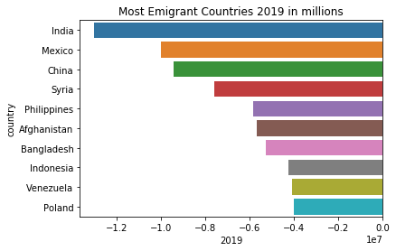

```python
sns.barplot(data=d_emi, x='2019', y='country', orient='horizontal', dodge=False).set_title('Most Emigrant Countries 2019 in millions')
```

7 of the top 10 emigrating countries are from Asia, with 1 each from Europe, North America and South America.

```
Text(0.5,1,'Most Immigrant Countries 2019 in millions')
```

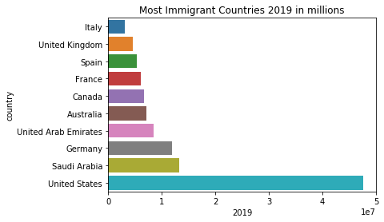

```python
sns.barplot(data=d_imm, x='2019', y='country', orient='horizontal', dodge=False).set_title('Most Immigrant Countries 2019 in millions')
```

5 of the top 10 immigrant countries are in Europe, 2 each in North America and the Middle East and Australia.

Line graphs are plotted to show changing patterns over a period of time in various countries

```
Text(0,0.5,'Population in -millions')
```

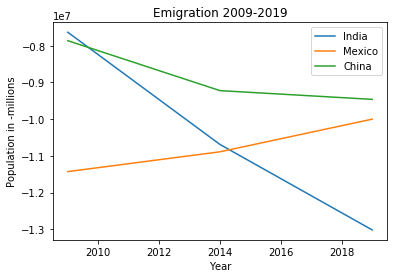

```python
bar_plot = pd.DataFrame({'India': [-7630000, -10690000, -13020000], 'Mexico': [-11430000, -10890000, -10000000], 'China': [-7860000, -9222000, -9460000]}, index=[2009, 2014, 2019])

ax=bar_plot.plot(kind = 'line', y = ['India', 'Mexico', 'China'])
ax.set_title("Emigration 2009-2019")
ax.set_xlabel("Year")
ax.set_ylabel("Population in -millions")
```

```
Text(0,0.5,'Population in -millions')
```

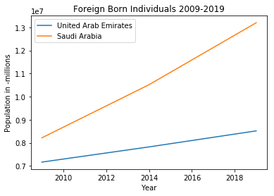

```python
bar_plot = pd.DataFrame({'United Arab Emirates': [7164000.0, 7822000.0, 8517000], 'Saudi Arabia': [8215000.0, 10517000.0, 13201000]}, index=[2009, 2014, 2019])

ax=bar_plot.plot(kind = 'line', y = ['United Arab Emirates', 'Saudi Arabia'])
ax.set_title("Foreign Born Individuals 2009-2019")
ax.set_xlabel("Year")
ax.set_ylabel("Population in -millions")
```

Foreign individuals are settling at an increasing rate in Saudi Arabia than United Arab Emirates.

1. Which countries have the highest increase of population through migration?

Top Three countries with highest population growth due to immigration:

i. United States

ii. Saudi Arabia

iii. Germany

1. Which countries have the highest decrease of population through migration?

Top three countries with population decline due to emigration:

i. India

ii. Mexico

iii. China

1. Which country most reduced emigration over the last 10 years?

The visualization shows that of the top 3 countries, Mexico has improved the most in stemming emigration.

1. Which Middle East country has a growing number of foreign born individuals?

Saudi Arabia. Foreign population in Saudi Arabia is growing faster than UAE.

Conclusion

From the analysis, the migration pattern of countries has shown the number of foreign born individuals in absolute values and the countries these individuals are leaving from.

Limitations

Exploration of the proportion that each country contributes to the other is not reflected.

This data can be further analyzed to define a relationships between the GDP of each country, conflict regions and type of governance to gain more insight to the causes of such migration patterns.

```python
from subprocess import call
call(['python', '-m', 'nbconvert', 'Investigate_a_Dataset.ipynb'])
```

```
0
```